# Part I - Exploring Ford GoBike System Data

## by Nsikanabasi Essiet

## Investigation Overview

> The overall goal of this presentation is to get insights of trips busiest and least busiest days, busiest trip take-off and ending times and How does bike_id and member_birth_year relate with member_gender, user_type, and bike_share_for_all_trip

## Dataset Overview

> Ford GoBike System Data includes information about individual rides made in a bike-sharing system covering the greater San Francisco Bay area in USA. In the dataset, there are 183412 records of fordgobike trips and 16 specifications.

## (Visualization 1: Barchart)

> Most trips start day is Thursday with trip frequency of 35197, followed by Tuesday with frequency of 31813. Saturday has the least frequency of 15405.

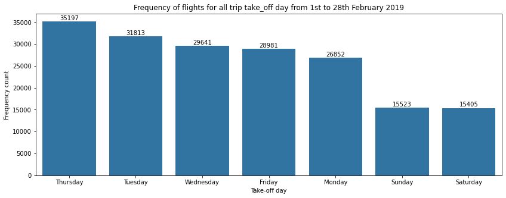

## (Visualization 2: Histogram)

> This is a log transformed histogram. It looks fairly symmetric with one prominent peak The graph shows that around 600 seconds have the largest frequency of about 25000. It seems most of the trips are below 1000 seconds duration.

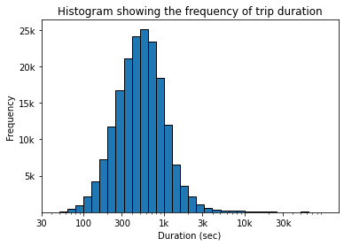

## (Visualization 3: Histogram)

The two histograms below show the frequencies of trips take-off and ending times. With bin size of 24 for both plots so that each bin represents a unique hour, the graphs are bi-modal and look roughly the same with 17:00 as the hour with highest trip take-off and ending, and 03:00 with the least.

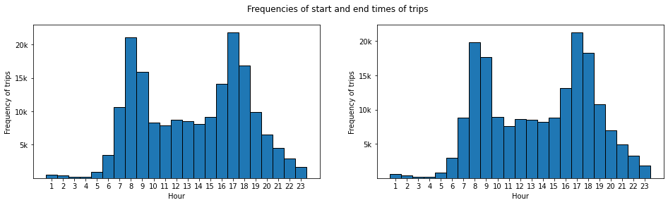